# Exploratory Analysis

By: Brandon Ly, Tiffany Tse, Meena Attringal, Fatin Almaroof

## Distribution of Variables

### Distribution of Depression Indicators

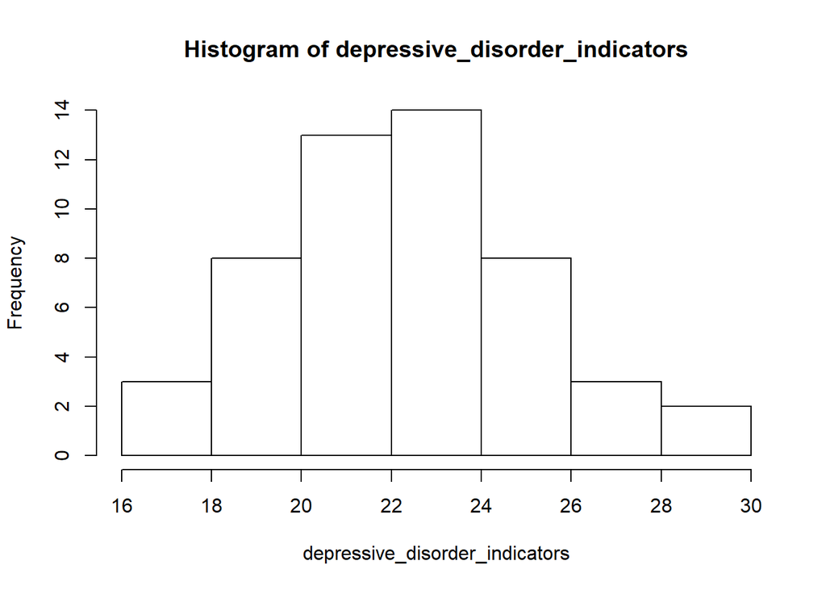

This graph showcases that indicators of Depression during the pandemic across the states in the USA. We can see that the ranges of indicators of depression ranges from 16 to 30, with most states falling in between 20 and 24. These values represent the the average number of indicators for depression among individuals. 14 States reported that their indicators of depression fell between 22 and 24. New York having the highest indicators of depression at 28.7, and Iowa being the lowest at 16.5. This could also be due to the population density of each state as well as the severity of COVID cases.

### Distribution of Anxiety Indicators

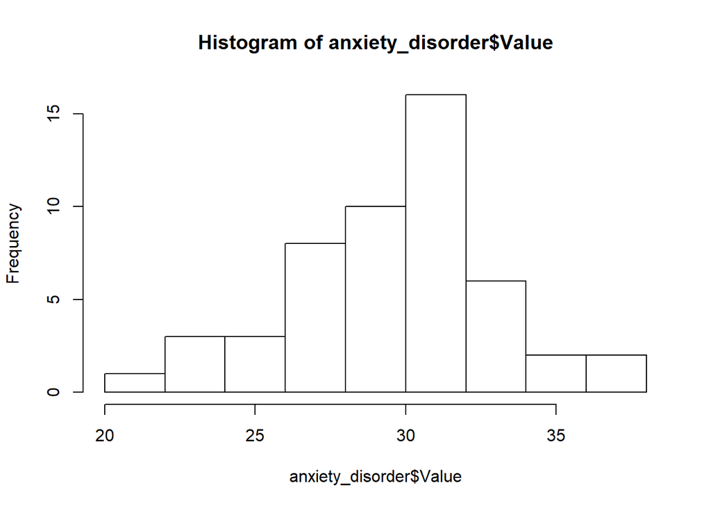

This graph shows the percentage of people experiencing anxiety indicators during the first phase of survey record taking (April 23-May 5, 2020). It is categorized by states in the US. From the histogram, we can see most states have about 20 to 40% of their population show symptoms of anxiety during this time period Most states (16 states) showed that 30% of their population indicated an anxiety disorder. The state with the lowest percentage of their population indicating symptoms of anxiety was North Dakota at 21.7% while the highest was Massachusetts at 37% of the population.

## Relationships Between Variables

### Covid-19 Status and Emotions

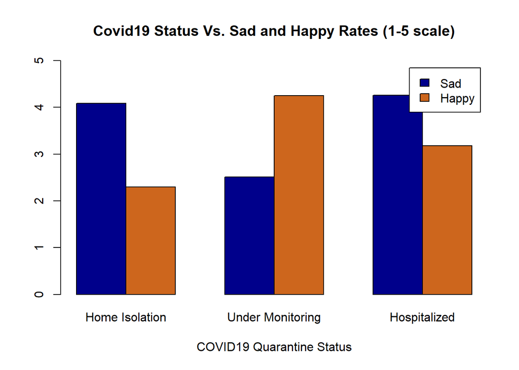

The visual bar graph shows the relationship between COVID-19. Quarantine Status Vs.Sad and Happy rates on a scale of 1-5. We can see that the sad rates for Home Isolation and Hospitalization are much higher than the happy rates. This makes sense since both these cases often imply that the person probably has very limited interaction with other people during their quarantine period. While some asymptomatic individuals usually quarantine but not self isolate, their happy rates are higher.

### Average Indicators of Depression and Anxiety Across Phases of The Pandemic

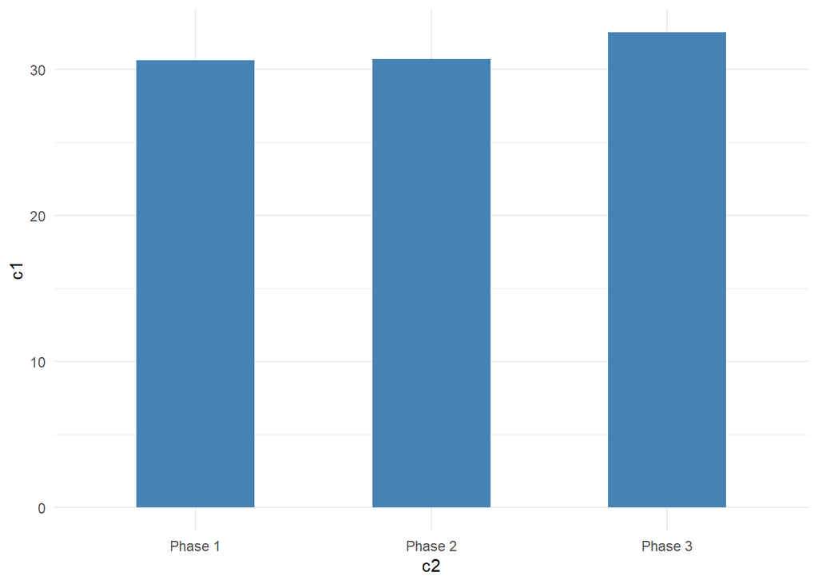

For this graph, we identified the average values collected for the first three phases of the CDC’s testing of the mental health of their sample population. This data is based on a survey that was “designed to gauge the impact of the pandemic on employment status, consumer spending, food security, housing, education disruptions, and dimensions of physical and mental wellness.” (CDC 2022). It shows that anxiety and mental health has only gotten worse throughout the pandemic.